# Analysis of DCA tagged coral data during PortMiami dredge

Ross Cunning, Rachel Silverstein

3/07/2018

## Import data

```r
# look at compliance data for all sites including hardbottom
head(compliance_alldata)
compliance_alldata2 <- with(compliance_alldata, {
  aggregate(data.frame(Condition.Codes=Condition.Code),
            by=list(Week=Week, Date=Date, Site=Site, Transect=Transect,
                    Coral.ID=Coral.ID, Species=Species),
            FUN=function(x) c(as.character(x)))
})
compliance_alldata2 <- compliance_alldata2[with(compliance_alldata2, order(Site, Transect, Coral.ID, Week)), ]

# FIX ERRORS
spp <- with(compliance_alldata2, aggregate(Species, by=list(Site=Site, Transect=Transect, Coral.ID=Coral.ID),
                     FUN=function(x) unique(c(as.character(x)))))
# There are several instances where a given Site-Transect-Coral.ID has multiple spp. assignments...
# Find which name was used most frequently for each Site-Transect-Coral.ID
which.spp <- with(compliance_alldata2, {
  aggregate(data.frame(Species=Species), by=list(Site=Site, Transect=Transect, Coral.ID=Coral.ID),
            FUN=function(x) {
              names(table(c(as.character(x))))[which.max(table(c(as.character(x))))]
            })
})

# Reassign all values of Species for each coral to the most freq used Species
for (i in 1:nrow(which.spp)) {
  compliance_alldata2[compliance_alldata2$Site==which.spp[i, "Site"] &
          compliance_alldata2$Transect==which.spp[i, "Transect"] &
          compliance_alldata2$Coral.ID==which.spp[i, "Coral.ID"],
          "Species"] <- which.spp[i, "Species"]
}

# Change Acerv WP to WB
cond <- compliance_alldata2[compliance_alldata2$Species=="ACER" & hasCond("^WP$", compliance_alldata2$Condition.Codes), "Condition.Codes"]
compliance_alldata2[compliance_alldata2$Species=="ACER" & hasCond("^WP$", compliance_alldata2$Condition.Codes), "Condition.Codes"] <- str_replace_all(cond, "WP", "WB")


# Where did disease first occur?
# Calculate frequency of WP at each Site on each Date
wp_cad <- compliance_alldata2 %>%
  group_by(Site, Date) %>%
  summarise(freq.WP=sum(hasCond("^WP$", Condition.Codes))/n())

wp_cad
View(wp_cad)
dim(wp_cad)
dim(na.omit(wp_cad))

# Find earliest Date WP was observed >0% across all sites
wp_cad %>%
  group_by(Site) %>%
  summarise(`First WP > 0%`=min(Date[freq.WP > 0])) %>%
  arrange(`First WP > 0%`) %>%
  knitr::kable()

# WP never observed at HBN2? etc
compliance_alldata2 %>%
  filter(Site=="HBN2", hasCond("^WP$", Condition.Codes))

hbspp <- compliance_alldata2 %>%
  filter(Week==1) %>%
  group_by(Site, Species) %>%
  summarise(n())

range(compliance_alldata2$Date)
#"90% of all DSTO got the disease", yet none at HBS3 and other HB sites?
compliance_alldata2 %>%
  filter(grepl("^HB", Site),
         )

compliance_alldata2 %>%
  filter(Site=="HBS3", hasCond("^WP$", Condition.Codes))
```

#### Check for conflicting species assignments for individual corals

```r
# How many corals have multiple species assignments? (e.g., indicative of an error in data entry)
spp <- with(alldata, aggregate(Species, by=list(Site=Site, Transect=Transect, Coral.ID=Coral.ID),
                     FUN=function(x) unique(c(as.character(x)))))
table(sapply(spp$x, length)>1)
```

```
##
## FALSE  TRUE
##   356    87
```

```r
capture.output(spp, file="all_spp_conflicts.txt")
```

#### Change conflicting species assignments to reflect most frequently assigned species

We attempt to fix some of these conflicting species assignments by changing species assignments for each coral (defined as unique site-transect-coralID) to the most frequently assigned species.

```r
# There are several instances where a given Site-Transect-Coral.ID has multiple spp. assignments...
# Find which name was used most frequently for each Site-Transect-Coral.ID
which.spp <- with(alldata, {
  aggregate(data.frame(Species=Species), by=list(Site=Site, Transect=Transect, Coral.ID=Coral.ID),
            FUN=function(x) {
              names(table(c(as.character(x))))[which.max(table(c(as.character(x))))]
            })
})

# Reassign all values of Species for each coral to the most freq used Species
for (i in 1:nrow(which.spp)) {
  alldata[alldata$Site==which.spp[i, "Site"] &
          alldata$Transect==which.spp[i, "Transect"] &
          alldata$Coral.ID==which.spp[i, "Coral.ID"],
          "Species"] <- which.spp[i, "Species"]
}
```

#### Identify colonies that died after having WP

```r
wpbeforedead <- alldata %>%
  group_by(coral) %>%
  summarise(WP = as.character(min(Date[hasCond("^WP$", Condition.Codes)])),
            DEAD = as.character(min(Date[hasCond("^DEAD$", Condition.Codes)]))) %>%
  drop_na() %>%
  mutate(WPbeforeDEAD = as.Date(WP) < as.Date(DEAD))

# For these corals that had WP before DEAD, change DEAD to WPDEAD
alldata[alldata$coral %in% wpbeforedead$coral & hasCond("DEAD", alldata$Condition.Codes), "Condition.Codes"] <- "WPDEAD"
```

#### Change *A. cervicornis* WP records to WB

```r
cond <- alldata[alldata$Species=="ACER" & hasCond("^WP$", alldata$Condition.Codes), "Condition.Codes"]
alldata[alldata$Species=="ACER" & hasCond("^WP$", alldata$Condition.Codes), "Condition.Codes"] <- str_replace_all(cond, "WP", "WB")
```

## Analyze results reported in Precht et al. 2016

```r
# Subset sites and date range analyzed in Precht et al. 2016
precht <- alldata %>%
  filter(Date >= "2013-10-19" & Date <= "2015-07-13",
         Site %in% c("R2NC1", "R2NC2", "R2SC1", "R2SC2")) %>%
  droplevels()
```

Block quotes are statements taken directly from the paper, and are followed by analysis attempting to evaluate and reproduce the claim.

### Dataset summary

> A total of 115 coral colonies, representing 13 coral species, were tagged for repeated monitoring at four sites on the inner reef tract in Miami-Dade County (Fig. 1). Coral colonies were monitored at least 40 times between October 19, 2013 and July 13, 2015.

Number of tagged corals:

```r
with(precht, nlevels(coral))
```

```
## [1] 115
```

```r
precht %>%
  group_by(Site) %>%
  summarise(n_corals = length(unique(coral)))
```

```
## # A tibble: 4 x 2
##   Site  n_corals
##   <fct>    <int>
## 1 R2NC1       30
## 2 R2NC2       30
## 3 R2SC1       30
## 4 R2SC2       25
```

Number of species:

```r
with(precht, nlevels(factor(Species)))
```

```
## [1] 13
```

```r
sort(unique(precht$Species))
```

```
##  [1] "AAGA" "ACER" "CNAT" "DCLI" "DSTO" "DSTR" "MCAV" "MMEA" "OFAV" "PAST"
## [11] "SBOU" "SINT" "SSID"
```

Number of times monitored:

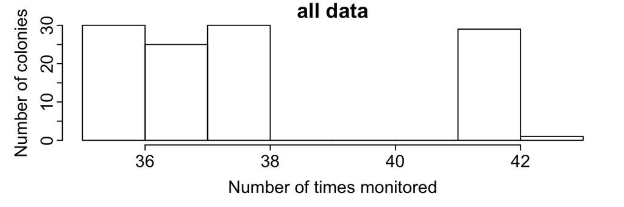

```r
n_times <- precht %>%
  group_by(coral) %>%
  summarise(n=nlevels(factor(Date)))
# Plot histogram of times observed
par(mar=c(3,3,1,1), mgp=c(1.5,0.25,0), tcl=-0.25)
hist(n_times$n, xlab="Number of times monitored", ylab="Number of colonies", main="all data")
```

Within this dataset, individual colonies were monitored between 35 and 43 times each. This is inconsistent with the statement that colonies were observed at least 40 times, and could mean that the dataset is incomplete.

### Peak of coral bleaching

> The peak of coral bleaching was recorded in September 2014. Specifically, the highest recorded bleaching prevalence occurred on September 12, 2014, when 84% (21 of 25 corals surveyed that day) showed signs of coral bleaching (Fig. 2).

```r
# Quantify bleaching (condition code "BL") on 9/12/14
precht %>%
  filter(Date=="2014-09-12") %>%
  summarise(Date=unique(Date), n=n(), BL=sum(hasCond("^BL$", Condition.Codes)), freq.BL=BL/n) %>%
  knitr::kable()
```

| Date | n | BL | freq.BL |
| --- | --- | --- | --- |
| 2014-09-12 | 25 | 4 | 0.16 |

```r
# Quantify bleaching or partial bleaching (condition codes "BL" or "PB") on 9/12/14
precht %>%
  filter(Date=="2014-09-12") %>%
  summarise(Date=unique(Date), n=n(), `BL or PB`=sum(hasCond("^BL$|^PB$", Condition.Codes)),
            freq.BLorPB=`BL or PB`/n) %>%
  knitr::kable()
```

| Date | n | BL or PB | freq.BLorPB |
| --- | --- | --- | --- |
| 2014-09-12 | 25 | 7 | 0.28 |

```r
# Quantify bleaching, partial bleaching, or paling (condition codes "BL", "PB", or "P") on 9/12/14
precht %>%
  filter(Date=="2014-09-12") %>%
  summarise(Date=unique(Date), n=n(), `BL, PB, or P`=sum(hasCond("^BL$|^PB$|^P$", Condition.Codes)),
            freq.BL_PB_P=`BL, PB, or P`/n) %>%
  knitr::kable()
```

| Date | n | BL, PB, or P | freq.BL_PB_P |
| --- | --- | --- | --- |
| 2014-09-12 | 25 | 21 | 0.84 |

The number of corals recorded as BL on September 12, 2014 was only 4 out of 25 (16%). The number of corals recorded as BL or PB was 7 (28%), and the number recorded as BL, PB, or P was 21 (84%).

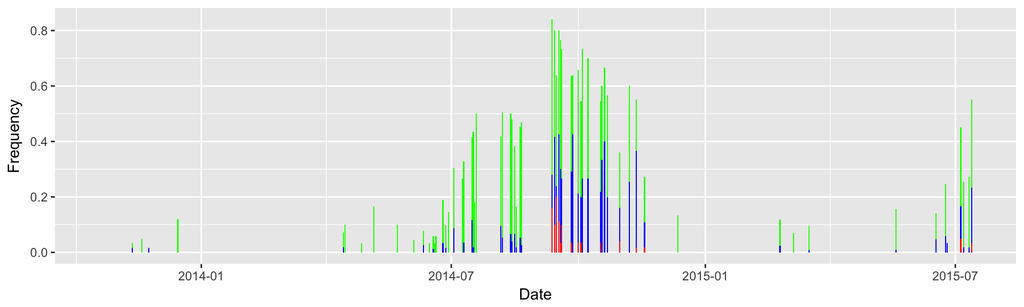

```r
# When was the peak of bleaching?
bleaching <- precht %>%
  group_by(Date) %>%
  summarise(n=n(),
            freq.BL=sum(hasCond("^BL$", Condition.Codes))/n,
            freq.BLorPB=sum(hasCond("^BL$|^PB$", Condition.Codes))/n,
            freq.BLorPBorP=sum(hasCond("^BL$|^PB$|^P$", Condition.Codes))/n)

# Plot frequency of bleaching codes recorded over time
ggplot(data=bleaching, mapping=aes(x=Date)) + ylab("Frequency") +
  geom_bar(aes(y=freq.BLorPBorP), stat="identity", fill="green") +  # Green is BL, PB, or P
  geom_bar(aes(y=freq.BLorPB), stat="identity", fill="blue") +  # Blue is BL or PB
  geom_bar(aes(y=freq.BL), stat="identity", fill="red")  # Red is BL only
```

```r
# Maximum frequency of BL
bleaching[which.max(bleaching$freq.BL), c("Date", "n", "freq.BL")] %>% knitr::kable()
```

| Date | n | freq.BL |
| --- | --- | --- |
| 2014-09-15 | 25 | 0.2 |

```r
# Maximum frequency of BL or PB
bleaching[which.max(bleaching$freq.BLorPB), c("Date", "n", "freq.BLorPB")] %>% knitr::kable()
```

| Date | n | freq.BLorPB |
| --- | --- | --- |
| 2014-09-27 | 61 | 0.4262295 |

```r
# Maximum frequency of BL or PB or P
bleaching[which.max(bleaching$freq.BLorPBorP), c("Date", "n", "freq.BLorPBorP")] %>% knitr::kable()
```

| Date | n | freq.BLorPBorP |
| --- | --- | --- |
| 2014-09-12 | 25 | 0.84 |

### First signs of white plague disease

> The first sign of a white-plague disease outbreak (prevalence > 5%) was noticed at the southern monitoring sites, near Virginia Key, on September 26, 2014…

```r
# Calculate frequency of WP at each Site on each Date
wp_precht <- precht %>%
  group_by(Site, Date) %>%
  summarise(freq.WP=sum(hasCond("^WP$", Condition.Codes))/n())

# What was the frequency of WP at the southern monitoring sites on September 26, 2014?
wp_precht %>% filter(Date=="2014-09-26", Site %in% c("R2SC1", "R2SC2")) %>% knitr::kable()
```

| Site | Date | freq.WP |
| --- | --- | --- |
| R2SC1 | 2014-09-26 | 0.00 |
| R2SC2 | 2014-09-26 | 0.04 |

These data show that the prevalence of WP on September 26, 2014 at the southern monitoring sites was 0% at R2SC1 and 4% at R2SC2.

```r
# Find earliest Date with WP frequency greater than 5% at each Site
wp_precht %>%
  group_by(Site) %>%
  summarise(`First WP > 5%`=min(Date[freq.WP > 0.05]),
            freq.WP=freq.WP[Date==`First WP > 5%`]) %>%
  knitr::kable()
```

| Site | First WP > 5% | freq.WP |
| --- | --- | --- |
| R2NC1 | 2015-06-17 | 0.0666667 |
| R2NC2 | 2015-05-19 | 0.1000000 |
| R2SC1 | 2014-12-12 | 0.0666667 |
| R2SC2 | 2014-10-17 | 0.0800000 |

We find that the first observation of ≥5% prevalence within the Precht et al. 2016 study sites was Oct 17 2014 at R2SC2, when the prevalence of WP was 8% of colonies.

Using the full dataset (all sites monitored), what was the first date that WP was observed at greater than 5% prevalence?

```r
# Calculate frequency of WP at each Site on each Date
wp_all <- alldata %>%
  group_by(Site, Date) %>%
  summarise(freq.WP=sum(hasCond("^WP$", Condition.Codes))/n())

# Find earliest Date WP was observed >5% across all sites
wp_all %>%
  group_by(Site) %>%
  summarise(`First WP > 5%`=min(Date[freq.WP > 0.05], na.rm=T)) %>%
  arrange(`First WP > 5%`) %>%
  knitr::kable()
```

| Site | First WP > 5% |
| --- | --- |
| R3NC1 | 2014-06-27 |
| R2SC2 | 2014-10-17 |
| R2N1 | 2014-11-13 |
| R2S1 | 2014-11-18 |
| R2S2 | 2014-11-18 |
| R2SC1 | 2014-12-12 |
| R3S3 | 2015-02-25 |
| R3SC2 | 2015-02-25 |
| R3SC3 | 2015-02-25 |
| R2NC2 | 2015-05-19 |
| R2NC1 | 2015-06-17 |
| R2NC3 | 2015-07-06 |
| R3SC1 | 2015-07-11 |
| R2N2 | 2015-07-15 |
| R3S2 | 2016-08-20 |
| R3N1 | NA |
| R3S1 | NA |

```r
# Find earliest Date WP was observed >0% across all sites
wp_all %>%
  group_by(Site) %>%
  summarise(`First WP > 0%`=min(Date[freq.WP > 0], na.rm=T)) %>%
  arrange(`First WP > 0%`) %>%
  knitr::kable()
```

| Site | First WP > 0% |
| --- | --- |
| R2N1 | 2013-10-23 |
| R3NC1 | 2014-06-27 |
| R2NC1 | 2014-08-13 |
| R3SC3 | 2014-09-25 |
| R2SC2 | 2014-09-26 |
| R2SC1 | 2014-10-03 |
| R2S2 | 2014-10-18 |
| R2NC2 | 2014-10-20 |
| R2S1 | 2014-10-22 |
| R3SC1 | 2014-11-13 |
| R2N2 | 2014-11-18 |
| R3S2 | 2014-12-14 |
| R3S3 | 2014-12-14 |
| R3SC2 | 2015-02-25 |
| R2NC3 | 2015-07-06 |
| R3N1 | NA |
| R3S1 | NA |

```r
# First observation at R2N1 on 10-23-2013
alldata %>%
  filter(Date=="2013-10-23",
         hasCond("^WP$", Condition.Codes))
```

```
##   Week       Date Site Transect Coral.ID Species Condition.Codes
## 1   BL 2013-10-23 R2N1        1        4    DSTO              WP
##       Channel reef dir    coral
## 1 channelside   R2   N R2N1.1.4
```

```r
# Find earliest Date with WP observed at all
wp_precht %>%
  group_by(Site) %>%
  summarise(`First WP > 0%`=min(Date[freq.WP > 0]),
            freq.WP=freq.WP[Date==`First WP > 0%`]) %>%
  knitr::kable()
```

| Site | First WP > 0% | freq.WP |
| --- | --- | --- |
| R2NC1 | 2014-08-13 | 0.0333333 |
| R2NC2 | 2014-10-20 | 0.0333333 |
| R2SC1 | 2014-10-03 | 0.0333333 |
| R2SC2 | 2014-09-26 | 0.0400000 |

```r
# Which coral had WP on June 20, 2014?
precht %>%
  filter(Date=="2014-06-20",
         hasCond("^WP$", Condition.Codes))
```

```
##  [1] Week            Date            Site            Transect
##  [5] Coral.ID        Species         Condition.Codes Channel
##  [9] reef            dir             coral
## <0 rows> (or 0-length row.names)
```

```r
# It's a cervicornis... this is believed to be changed from WP to WB in later QC...

precht %>%
  filter(Date=="2014-08-13",
         hasCond("^WP$", Condition.Codes))
```

```
##   Week       Date  Site Transect Coral.ID Species Condition.Codes Channel
## 1   39 2014-08-13 R2NC1        3        8    DSTO         UPM, WP control
##   reef dir     coral
## 1   R2   N R2NC1.3.8
```

```r
allwp <- alldata %>%
  group_by(Date, WP = hasCond("^WP$", Condition.Codes), Species) %>%
  summarise(n()) %>%
  filter(WP) %>%
  arrange(Date)
```

### White plague disease prevalence and dynamics

> …by November 18, 15% of the tagged colonies showed outward signs of white-plague disease (Fig. 2).

```r
# How many colonies had WP on November 18th, 2015?
precht %>%
  filter(Date=="2014-11-18") %>%
  summarise(Date=unique(Date),
            n=n(),
            WP=sum(hasCond("^WP$", Condition.Codes)),
            freq.WP=WP/n) %>%
  knitr::kable()
```

| Date | n | WP | freq.WP |
| --- | --- | --- | --- |
| 2014-11-18 | 55 | 6 | 0.1090909 |

We find that only 6 of 55 colonies (10.9%) observed on November 18th were recorded with the WP condition code.

```r
# How many colonies had WP or were WPDEAD on November 18th, 2015?
precht %>%
  filter(Date=="2014-11-18") %>%
  summarise(Date=unique(Date),
            n=n(),
            WPorDEAD=sum(hasCond("^WP$|^WPDEAD$", Condition.Codes)),
            freq.WPorDEAD=WPorDEAD/n) %>%
  knitr::kable()
```

| Date | n | WPorDEAD | freq.WPorDEAD |
| --- | --- | --- | --- |
| 2014-11-18 | 55 | 7 | 0.1272727 |

If both WP or WPDEAD are counted on November 18th, 2015, the frequency is 12.7% (7 out of 55). We are unable to reproduce the 15% number reported in the study.

> White-plague disease did not impact the northern monitoring sites (14 km north) until June 2015.

```r
# When was WP first observed at ≥5% prevalence at the northern sites?
wp_precht %>%
  filter(Site %in% c("R2NC1", "R2NC2")) %>%
  group_by(Site) %>%
  summarise(`First WP > 5%`=min(Date[freq.WP > 0.05]),
            freq.WP=freq.WP[Date==`First WP > 5%`]) %>%
  knitr::kable()
```

| Site | First WP > 5% | freq.WP |
| --- | --- | --- |
| R2NC1 | 2015-06-17 | 0.0666667 |
| R2NC2 | 2015-05-19 | 0.1000000 |

We find that WP was first observed ≥5% at the northern sites in *May 2015*.

> During the week of June 17 [2015], 17% of the tagged coral colonies at the northern monitoring sites were infected with white-plague disease.

```r
# How many corals at northern sites had WP on June 17, 2015?
precht %>%
  filter(Site %in% c("R2NC1", "R2NC2"), Date=="2015-06-17") %>%
  summarise(Date=unique(Date),
            n=n(),
            WP=sum(hasCond("^WP$", Condition.Codes)),
            freq.WP=WP/n) %>%
  knitr::kable()
```

| Date | n | WP | freq.WP |
| --- | --- | --- | --- |
| 2015-06-17 | 60 | 6 | 0.1 |

```r
# How many corals at northern sites had WP or WPDEAD on June 17, 2015?
precht %>%
  filter(Site %in% c("R2NC1", "R2NC2"), Date=="2015-06-17") %>%
  summarise(Date=unique(Date),
            n=n(),
            WPorWPDEAD=sum(hasCond("^WP$|^WPDEAD$", Condition.Codes)),
            freq.WPorWPDEAD=WPorWPDEAD/n) %>%
  knitr::kable()
```

| Date | n | WPorWPDEAD | freq.WPorWPDEAD |
| --- | --- | --- | --- |
| 2015-06-17 | 60 | 8 | 0.1333333 |

We find that out of 60 corals at the northern monitoring sites, 6 (10%) were observed with WP on June 17th, 2015. If WP and corals DEAD after WP are counted, it is 8 out of 60 (13%).

> In total, white-plague disease was observed on seven of the 13 coral species identified at the four permanent monitoring sites (Table 1).

[output not shown]

We find that 7 species were impacted by WP – this includes A cervicornis which we believe later was changed during additional QC to distinguish this as a different disease.

> The highest recorded prevalence of white-plague disease occurred on July 7, 2015, when 40% (22 of 55 corals surveyed that day) showed signs of white-plague disease infection (Fig. 2).

```r
# What is prevalence of WP on July 7th, 2015?
precht %>%
  filter(Date=="2015-07-07") %>%
  summarise(Date=unique(Date), n=n(),
            WP=sum(hasCond("^WP$", Condition.Codes)),
            freq.WP=WP/n) %>%
  knitr::kable()
```

| Date | n | WP | freq.WP |
| --- | --- | --- | --- |
| 2015-07-07 | 55 | 3 | 0.0545455 |

```r
precht %>%
  filter(Date=="2015-07-07") %>%
  summarise(Date=unique(Date), n=n(),
            WPorWPDEAD=sum(hasCond("^WP$|^WPDEAD$", Condition.Codes)),
            freq.WPorWPDEAD=WPorWPDEAD/n) %>%
  knitr::kable()
```

| Date | n | WPorWPDEAD | freq.WPorWPDEAD |
| --- | --- | --- | --- |
| 2015-07-07 | 55 | 16 | 0.2909091 |

We find that on July 7, 2015, only 3 out of 55 corals observed (5.5%) were recorded as having WP. If we include corals that were recorded as having WP *and* corals that were previously recorded as having WP and are now recorded as dead (despite the fact the paper claims to be reporting corals that “showed signs of white-plague infection”), the total is 16 out of 55, or 29.1%. Therefore, we are unable to reproduce the result reported in the paper with the provided data.

When was the highest recorded prevalence of WP?

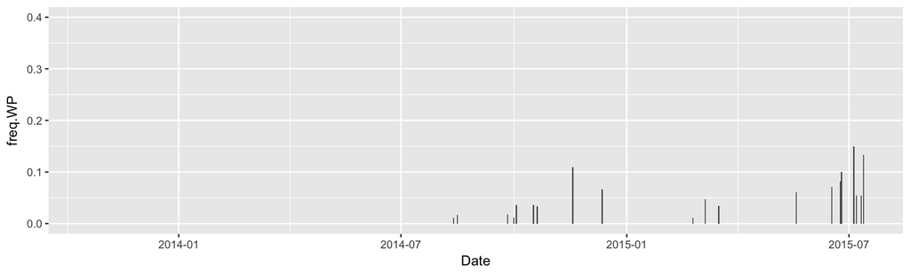

```r
# Graph white plague prevalence by Date (for all corals surveyed - may include multiple sites)
precht_wp_by_date <- precht %>%
  group_by(Date) %>%
  summarise(n=n(), WP=sum(hasCond("^WP$", Condition.Codes)), freq.WP=WP/n)

ggplot(data=precht_wp_by_date, aes(x=Date, y=freq.WP)) + ylim(0,0.4) + geom_bar(stat="identity")
```

```r
with(precht_wp_by_date, precht_wp_by_date[which.max(freq.WP), ]) %>% knitr::kable()
```

| Date | n | WP | freq.WP |
| --- | --- | --- | --- |
| 2015-07-05 | 60 | 9 | 0.15 |

We find that the highest prevalence of WP on any Date (all sites observed) was 15% (9 of 60 colonies) on July 5th, 2015.

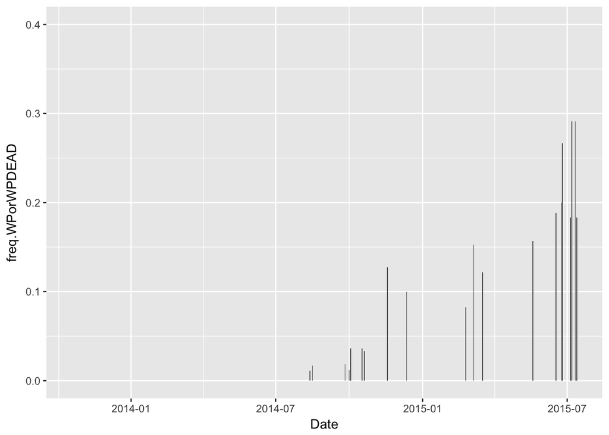

```r
# Graph prevalence of WP or WPDEAD
precht_wporwpdead_by_date <- precht %>%
  group_by(Date) %>%
  summarise(n=n(), WPorWPDEAD=sum(hasCond("^WP$|^WPDEAD$", Condition.Codes)),
            freq.WPorWPDEAD=WPorWPDEAD/n)

ggplot(data=precht_wporwpdead_by_date, aes(x=Date, y=freq.WPorWPDEAD)) + ylim(0,0.4) + geom_bar(stat="identity")
```

```r
with(precht_wporwpdead_by_date, precht_wporwpdead_by_date[which.max(freq.WPorWPDEAD), ]) %>% knitr::kable()
```

| Date | n | WPorWPDEAD | freq.WPorWPDEAD |
| --- | --- | --- | --- |
| 2015-07-07 | 55 | 16 | 0.2909091 |

If we count corals that have active white plauge disease (WP) *and* corals that previously had WP disease and are now dead, we find that the highest prevalence on any date is 16 out of 55 (29.1%) on July 7th, 2015.

> Of the white-plague impacted species, the overall disease prevalence was 51% (35 of 69 corals surveyed).

```r
# Susceptible species:
sus <- c("CNAT", "DSTO", "DLAB", "EFAS", "MMEA", "MCAV", "ODIF", "DCLI", "DSTR", "SBOU")

precht_wp.corals <- precht %>%
  filter(Species %in% sus) %>%
  group_by(Species, coral) %>%
  summarise(WP=any(hasCond("^WP$", Condition.Codes))) %>%
  select(WP) %>% table()

knitr::kable(rbind(precht_wp.corals, TOTAL=colSums(precht_wp.corals)))
```

|  | FALSE | TRUE |
| --- | --- | --- |
| CNAT | 1 | 0 |
| DCLI | 4 | 2 |
| DSTO | 4 | 6 |
| DSTR | 1 | 3 |
| MCAV | 17 | 10 |
| MMEA | 2 | 7 |
| SBOU | 10 | 2 |
| TOTAL | 39 | 30 |

We find that 30 out of 69 colonies (43.5%) were recorded as having WP at any point in time.

### Relationship between bleaching and disease

> The majority (81%) of white-plague susceptible corals bleached, prior to becoming infected with the disease (Table 1). *Meandrina meandrites*, *Dichocoenia stokesi*, *Colpophyllia natans*, and *Pseudodiploria strigosa* were the most heavily impacted coral species, with 100% of tagged colonies being afflicted with white-plague disease. All colonies that showed signs of disease died, regardless of species.

```r
# Get list of WP-affected corals
precht_wp.corals <- precht %>%
  filter(Species %in% sus) %>%
  group_by(coral) %>%
  summarise(WP=any(hasCond("^WP$", Condition.Codes))) %>%
  filter(WP==TRUE)

# How many WP-affected corals bleached prior to becoming infected?
precht_bleach_dis <- precht %>%
  filter(coral %in% precht_wp.corals$coral) %>%
  group_by(coral) %>%
  summarise(`P date`=min(Date[hasCond("^P$", Condition.Codes)]),
            `PB date`=min(Date[hasCond("^PB$", Condition.Codes)]),
            `BL date`=min(Date[hasCond("^BL$", Condition.Codes)]),
            `WP date`=min(Date[hasCond("^WP$", Condition.Codes)])) %>%
  arrange(`BL date`, `PB date`, `P date`, `WP date`)

knitr::kable(precht_bleach_dis)
```

| coral | P date | PB date | BL date | WP date |
| --- | --- | --- | --- | --- |
| R2SC2.2.3 | 2014-07-18 | 2014-09-17 | 2014-09-12 | 2014-10-17 |
| R2SC2.2.1 | 2014-08-14 | 2014-09-17 | 2014-09-12 | 2014-09-26 |
| R2SC1.1.3 | 2014-07-17 | 2014-09-17 | 2014-09-18 | 2014-11-18 |
| R2NC1.3.5 | 2014-06-04 | 2013-11-12 | NA | 2015-06-24 |
| R2NC2.1.4 | 2014-06-15 | 2014-07-03 | NA | 2015-05-19 |
| R2NC1.3.8 | 2014-07-16 | 2014-07-03 | NA | 2014-08-13 |
| R2SC2.3.9 | 2014-06-29 | 2014-07-10 | NA | 2014-11-18 |
| R2SC1.2.1 | 2014-05-06 | 2014-08-07 | NA | 2014-10-03 |
| R2NC1.3.1 | 2014-07-16 | 2014-09-14 | NA | 2015-05-19 |
| R2NC2.1.5 | 2014-08-07 | 2014-09-14 | NA | 2014-10-20 |
| R2SC1.3.1 | 2014-04-14 | 2014-09-17 | NA | 2015-06-25 |
| R2SC2.2.7 | 2014-07-03 | 2014-09-17 | NA | 2014-11-18 |
| R2SC2.1.1 | 2014-07-10 | 2014-09-17 | NA | 2014-11-18 |
| R2NC2.2.8 | 2014-07-19 | 2014-09-17 | NA | 2015-05-19 |
| R2SC1.2.6 | 2014-08-17 | 2014-09-17 | NA | 2015-03-06 |
| R2NC2.3.10 | 2014-08-21 | 2014-09-17 | NA | 2015-07-13 |
| R2SC1.1.4 | 2014-06-25 | 2014-09-18 | NA | 2015-03-06 |
| R2SC2.3.10 | 2013-12-15 | 2014-09-26 | NA | 2015-02-24 |
| R2NC2.2.5 | 2014-08-07 | 2014-09-27 | NA | 2015-07-05 |
| R2NC2.1.3 | 2014-08-20 | 2014-09-27 | NA | 2015-05-19 |
| R2NC2.1.9 | 2014-08-06 | 2014-10-04 | NA | 2015-07-05 |
| R2NC2.3.2 | 2014-07-03 | 2014-10-08 | NA | 2015-06-17 |
| R2SC1.1.2 | 2014-05-23 | NA | NA | 2015-05-19 |
| R2SC1.3.5 | 2014-06-25 | NA | NA | 2014-12-12 |
| R2SC1.1.6 | 2014-06-25 | NA | NA | 2014-12-12 |
| R2NC1.3.6 | 2014-07-03 | NA | NA | 2015-06-17 |
| R2SC1.1.10 | 2014-07-09 | NA | NA | 2015-03-17 |
| R2SC1.1.9 | 2014-08-20 | NA | NA | 2015-03-06 |
| R2SC2.1.5 | 2014-09-17 | NA | NA | 2014-11-18 |
| R2NC2.3.4 | 2014-09-17 | NA | NA | 2015-06-17 |

```r
# Calculate number of corals with either BL, PB, or P prior to WP
precht_bleach_dis %>%
  summarise(`n with WP`=n(),
            `BL first`=sum(`BL date` < `WP date`),
            `PB first`=sum(`PB date` < `WP date`),
            `P first`=sum(`P date` < `WP date`))
```

```
## # A tibble: 1 x 4
##   `n with WP` `BL first` `PB first` `P first`
##         <int>      <int>      <int>     <int>
## 1          30          3         22        30
```

We find that only 3 out of 30 corals (10%) that had WP were recorded as bleached (BL) prior to becoming infected. 22 out of 30 (73.3%) were recorded as partially bleached (PB) prior to infection, while 30 out of 30 (100%) were recorded as pale (P) prior to infection. The designation of pale does not necessarily indicate bleaching, since corals typically pale in summer months even in the absence of bleaching.

However, to properly and statistically assess whether there is a relationship between bleaching and disease, the number of corals that bleached and did NOT get disease must also be considered.

```r
# How many corals bleached but did NOT get WP disease?
blwp <- precht %>%
  filter(Species %in% sus) %>%
  group_by(coral) %>%
  summarise(BL=any(hasCond("^BL$", Condition.Codes)),
            BLorPB=any(hasCond("^BL$|^PB$", Condition.Codes)),
            BLorPBorP=any(hasCond("^BL$|^PB$|^P$", Condition.Codes)),
            WP=any(hasCond("^WP$", Condition.Codes)))

# Note that this analysis needs to be improved by incorporating the time component -- currently, this code only looks at whether corals were recorded as BL/PB and WP, but not when.

res <- with(blwp, table(BLorPB, WP))
addmargins(res)
```

```
##        WP
## BLorPB  FALSE TRUE Sum
##   FALSE    11    8  19
##   TRUE     28   22  50
##   Sum      39   30  69
```

```r
fisher.test(res)
```

```
##
##  Fisher's Exact Test for Count Data
##
## data:  res
## p-value = 1
## alternative hypothesis: true odds ratio is not equal to 1
## 95 percent confidence interval:
##  0.3283842 3.6702509
## sample estimates:
## odds ratio
##   1.079123
```

We find that 50 of the 69 disease-susceptible corals ‘bleached’ (BL or PB), and of these, 22 got WP disease (44%), but 28 did not (56%). We find a similar incidence of disease among corals that did not bleach, with 8 out of 19 (42%) having the disease, and 11 (58%) not having disease. With Fisher’s exact test, we find no relationship between bleaching (BL or PB) and disease (WP) (p-value=1).

### Relationship between sedimentation stress and disease

```r
# How many corals had sedimentation stress and disease?
sedwp <- precht %>%
  filter(Species %in% sus) %>%
  group_by(coral) %>%
  summarise(SED=any(hasCond("^SED$", Condition.Codes)),
            SA=any(hasCond("^SA$", Condition.Codes)),
            PBUR=any(hasCond("^PBUR$", Condition.Codes)),
            BUR=any(hasCond("^BUR$", Condition.Codes)),
            PBURorBUR=any(hasCond("^PBUR$|^BUR$", Condition.Codes)),
            SAorPBUR=any(hasCond("^SA$|^PBUR$", Condition.Codes)),
            WP=any(hasCond("^WP$", Condition.Codes)))

# Note that this analysis needs to be improved by incorporating the time component -- currently, this code only looks at whether corals were recorded as SED/SA/PBUR/BUR and WP, but not when.

res <- with(sedwp, table(SA, WP))
addmargins(res)
```

```
##        WP
## SA      FALSE TRUE Sum
##   FALSE    11    7  18
##   TRUE     28   23  51
##   Sum      39   30  69
```

```r
fisher.test(res)
```

```
##
##  Fisher's Exact Test for Count Data
##
## data:  res
## p-value = 0.7841
## alternative hypothesis: true odds ratio is not equal to 1
## 95 percent confidence interval:
##  0.3813444 4.5930404
## sample estimates:
## odds ratio
##    1.28608
```

```r
# There is no significant relationship between any of these factors and WP.
```

How many corals were recorded as WP but then did not die?

```r
# Get list of WP-affected corals prior to 07-13-2015
all_wp.corals <- alldata %>%
  filter(Species %in% sus, Date < "2015-07-15") %>%
  group_by(coral) %>%
  summarise(WP=any(hasCond("^WP$", Condition.Codes))) %>%
  filter(WP==TRUE)
all_wp.corals
```

```
## # A tibble: 87 x 2
##    coral     WP
##    <fct>     <lgl>
##  1 R2SC2.1.1 TRUE
##  2 R3S3.1.1  TRUE
##  3 R2S1.2.1  TRUE
##  4 R2S2.2.1  TRUE
##  5 R2SC1.2.1 TRUE
##  6 R2SC2.2.1 TRUE
##  7 R2NC1.3.1 TRUE
##  8 R2S2.3.1  TRUE
##  9 R2SC1.3.1 TRUE
## 10 R2S2.1.2  TRUE
## # ... with 77 more rows
```

```r
wp_dead <- alldata %>%
  filter(Site %in% c("R2SC1", "R2SC2", "R2NC1", "R2NC2")) %>%
  filter(coral %in% all_wp.corals$coral) %>%
  group_by(coral) %>%
  summarise(wpthendied = any(hasCond("DEAD", Condition.Codes)))
wp_dead
```

```
## # A tibble: 30 x 2
##    coral     wpthendied
##    <fct>     <lgl>
##  1 R2SC2.1.1 TRUE
##  2 R2SC1.2.1 TRUE
##  3 R2SC2.2.1 TRUE
##  4 R2NC1.3.1 TRUE
##  5 R2SC1.3.1 FALSE
##  6 R2SC1.1.2 FALSE
##  7 R2NC2.3.2 FALSE
##  8 R2NC2.1.3 FALSE
##  9 R2SC1.1.3 TRUE
## 10 R2SC2.2.3 TRUE
## # ... with 20 more rows
```

```r
table(wp_dead$wpthendied)
```

```
##
## FALSE  TRUE
##    10    20
```

```r
# corals that were recorded as WP but were not ever recorded as DEAD
getCoral(alldata, "R2NC1", 2, 1) %>% arrange(Date)
```

```
##    Week       Date  Site Transect Coral.ID Species Condition.Codes Channel
## 1    BL 2013-11-02 R2NC1        2        1    MCAV              PE control
## 2    BL 2013-11-12 R2NC1        2        1    MCAV              PE control
## 3    BL 2013-11-19 R2NC1        2        1    MCAV              PE control
## 4    BL 2013-11-24 R2NC1        2        1    MCAV              PE control
## 5     9 2014-01-18 R2NC1        2        1    MCAV            NONE control
## 6    21 2014-04-15 R2NC1        2        1    MCAV            NONE control
## 7    29 2014-06-04 R2NC1        2        1    MCAV            NONE control
## 8    30 2014-06-11 R2NC1        2        1    MCAV              PE control
## 9    31 2014-06-18 R2NC1        2        1    MCAV              PE control
## 10   31 2014-06-20 R2NC1        2        1    MCAV             SED control
## 11   32 2014-06-25 R2NC1        2        1    MCAV            NONE control
## 12   32 2014-06-27 R2NC1        2        1    MCAV            NONE control
## 13   33 2014-07-03 R2NC1        2        1    MCAV             SED control
## 14   35 2014-07-16 R2NC1        2        1    MCAV           P, PE control
```

[output cut: 59 more lines]

```r
getCoral(alldata, "R2SC1", 3, 1) %>% arrange(Date)
```

```
##    Week       Date  Site Transect Coral.ID Species Condition.Codes Channel
## 1    BL 2013-10-19 R2SC1        3        1    SBOU                 control
## 2    BL 2013-11-02 R2SC1        3        1    SBOU                 control
## 3    BL 2013-11-12 R2SC1        3        1    SBOU                 control
## 4    BL 2013-11-18 R2SC1        3        1    SBOU              PE control
## 5     9 2014-01-15 R2SC1        3        1    SBOU            NONE control
## 6    21 2014-04-14 R2SC1        3        1    SBOU          P, SED control
## 7    23 2014-04-27 R2SC1        3        1    SBOU            NONE control
## 8    23 2014-04-28 R2SC1        3        1    SBOU          SA, PD control
## 9    24 2014-05-06 R2SC1        3        1    SBOU      PE, SED, P control
## 10   27 2014-05-23 R2SC1        3        1    SBOU       SA, M, PE control
## 11   27 2014-05-25 R2SC1        3        1    SBOU              PE control
## 12   29 2014-06-04 R2SC1        3        1    SBOU     PE, SED, UC control
## 13   30 2014-06-11 R2SC1        3        1    SBOU     SA, PE, SED control
## 14   31 2014-06-19 R2SC1        3        1    SBOU         PE, SED control
```

[output cut: 73 more lines]

```r
getCoral(alldata, "R2SC1", 1, 2) %>% arrange(Date)
```

```
##    Week       Date  Site Transect Coral.ID Species Condition.Codes Channel
## 1    BL 2013-10-19 R2SC1        1        2    DSTR                 control
## 2    BL 2013-11-02 R2SC1        1        2    DSTR                 control
## 3    BL 2013-11-12 R2SC1        1        2    DSTR                 control
## 4    BL 2013-11-18 R2SC1        1        2    DSTR              SA control
## 5     9 2014-01-15 R2SC1        1        2    DSTR              SA control
## 6    21 2014-04-14 R2SC1        1        2    DSTR             SED control
## 7    23 2014-04-27 R2SC1        1        2    DSTR            NONE control
## 8    23 2014-04-28 R2SC1        1        2    DSTR             SED control
## 9    24 2014-05-06 R2SC1        1        2    DSTR            NONE control
## 10   27 2014-05-23 R2SC1        1        2    DSTR           SA, P control
## 11   27 2014-05-25 R2SC1        1        2    DSTR             SED control
## 12   29 2014-06-04 R2SC1        1        2    DSTR              SA control
## 13   30 2014-06-11 R2SC1        1        2    DSTR           SA, P control
## 14   31 2014-06-19 R2SC1        1        2    DSTR             SED control
```

[output cut: 73 more lines]

```r
getCoral(alldata, "R2NC2", 3, 2) %>% arrange(Date)
```

```
##    Week       Date  Site Transect Coral.ID Species Condition.Codes Channel
## 1    BL 2013-11-19 R2NC2        3        2    MCAV                 control
## 2    BL 2013-11-24 R2NC2        3        2    MCAV                 control
## 3    BL 2013-12-02 R2NC2        3        2    MCAV              PE control
## 4    29 2014-06-04 R2NC2        3        2    MCAV            NONE control
## 5    30 2014-06-11 R2NC2        3        2    MCAV            NONE control
## 6    30 2014-06-15 R2NC2        3        2    MCAV              PE control
## 7    31 2014-06-18 R2NC2        3        2    MCAV             SED control
## 8    31 2014-06-20 R2NC2        3        2    MCAV              PE control
## 9    32 2014-06-25 R2NC2        3        2    MCAV              PE control
## 10   32 2014-06-27 R2NC2        3        2    MCAV            NONE control
## 11   33 2014-07-03 R2NC2        3        2    MCAV           PE, P control
## 12   34 2014-07-10 R2NC2        3        2    MCAV         PE, SED control
## 13   35 2014-07-16 R2NC2        3        2    MCAV          PE, SA control
## 14   35 2014-07-19 R2NC2        3        2    MCAV               P control
```

[output cut: 65 more lines]

How many colonies died that were not among the ‘susceptible’ species?

```r
nonsusdead <- alldata %>%
  filter(!(Species %in% sus),
         Site %in% c("R2SC1", "R2SC2", "R2NC1", "R2NC2")) %>%
  group_by(coral) %>%
  mutate(died = any(hasCond("DEAD", Condition.Codes))) %>%
  filter(died == TRUE)

unique(nonsusdead$coral)  # 7 corals of non-susceptible species died (at the R2 control sites)
```

```
## [1] R2SC2.2.4  R2SC2.1.2  R2SC2.1.3  R2SC2.1.6  R2NC1.1.6  R2NC1.3.10
## [7] R2SC2.3.2
## 443 Levels: R2N1.1.1 R2N2.1.1 R2NC1.1.1 R2NC2.1.1 R2NC3.1.1 ... R3S2.3.10
```

how many corals WP or WPDEAD at all Sites by July 15 2015

```r
d1 <- alldata %>%
  filter(Date <= "2015-07-15") %>%
  group_by(Site, coral) %>%
  summarise(WPorWPDEAD = any(hasCond("^WP$|^WPDEAD$", Condition.Codes))) %>%
  ungroup() %>% group_by(Site) %>%
  summarise(n = n(), WPorWPDEAD = sum(WPorWPDEAD), freq = WPorWPDEAD / n)
d1
```

```
## # A tibble: 17 x 4
##    Site      n WPorWPDEAD   freq
##    <fct> <int>      <int>  <dbl>
##  1 R2N1     30          7 0.233
##  2 R2N2     25          3 0.120
##  3 R2NC1    30          4 0.133
##  4 R2NC2    30          9 0.300
##  5 R2NC3    30          2 0.0667
##  6 R2S1     28          8 0.286
##  7 R2S2     24         11 0.458
##  8 R2SC1    30         10 0.333
##  9 R2SC2    25          8 0.320
## 10 R3N1     24          0 0.
## 11 R3NC1    24          6 0.250
## 12 R3S1     19          0 0.
## 13 R3S2     25          3 0.120
## 14 R3S3     26          9 0.346
## 15 R3SC1    25          4 0.160
## 16 R3SC2    23          3 0.130
## 17 R3SC3    25          6 0.240
```

```r
write.table(d1, file="WPorWPDEAD_byJuly152015.txt", row.names=F, quote=F)
```

## Analyze dredging impacts

```r
alldata <- as_tibble(alldata)
alldata
```

```
## # A tibble: 15,003 x 11
##    Week  Date       Site  Transect Coral.ID Species Condition.Codes
##  * <chr> <date>     <fct> <chr>       <int> <chr>   <list>
##  1 BL    2013-11-12 R2NC1 2               9 PAST    <chr [0]>
##  2 BL    2013-11-19 R2NC1 2               9 PAST    <chr [0]>
##  3 BL    2013-11-21 R2SC2 2               4 AAGA    <chr [0]>
##  4 BL    2013-12-02 R2SC2 2               4 AAGA    <chr [0]>
##  5 BL    2013-12-10 R2SC2 2               4 AAGA    <chr [0]>
##  6 BL    2013-12-15 R2SC2 2               4 AAGA    <chr [0]>
##  7 BL    2013-11-21 R2SC2 1               2 ACER    <chr [0]>
##  8 BL    2013-12-02 R2SC2 1               2 ACER    <chr [0]>
##  9 BL    2013-12-10 R2SC2 1               2 ACER    <chr [0]>
## 10 BL    2013-12-15 R2SC2 1               2 ACER    <chr [0]>
## # ... with 14,993 more rows, and 4 more variables: Channel <chr>,
## #   reef <chr>, dir <chr>, coral <fct>
```